# Automated Glioblastoma Tumor Segmentation

MRI T1 and FLAIR images enable visualization of tumor segmentation. The code below utilizes the provided FLAIR and T1 image to perform automated tumor segmentation and generate the following label files:

- Total tumor (from FLAIR image).
- Tumor bulk (from T1), which consists of the contrast enhancing (CE) and necrotic (NE) parts of the tumor.

Additionally, it computes the dice coefficient of overlap between the tumor bulk and the provided label file to evaluate accuracy

## Methodology

The following steps are executed to obtain the segmentation:

- Registration of FLAIR to T1 image
- Skull stripping of T1 and FLAIR images using atlas based segmentation
- Total tumor segmentation from FLAIR
  - Automated thresholding for initial segmentation of hyperintense region
  - Refinement using shape and size constraints to segment tumor
- Segmentation of tumor bulk from T1
  - Thresholding to obtain CE region
  - NE region: Level set segmentation using eroded total tumor mask from FLAIR as initialization
- Computation of dice coefficient of overlap

In [1] a semi-automated method using FSLView was used to obtain the total tumor and tumor bulk segmentation. Fully automated tumor segmentation approaches in the recent past rely on machine learning techniques such as in [2], where voxel-wise classification was performed. Since I was provided one image, I introduced shape and size constraints to segment the tumor.

```python
import matplotlib.pyplot as plt
%matplotlib inline
from __future__ import print_function
import display_utilities as disp
import SimpleITK as sitk
import numpy as np
```

Read images and rescale to 0-255 for visualization purposes

```python
img_T1 = sitk.ReadImage('../Data/3D_WAND_T1_WEIGHTED.nrrd', sitk.sitkFloat32)
img_FLAIR = sitk.ReadImage('../Data/AX_FLAIR.nrrd', sitk.sitkFloat32)

# To visualize the labels image in RGB with needs a image with 0-255 range
img_T1_255 = sitk.Cast(sitk.RescaleIntensity(img_T1), sitk.sitkUInt8)
img_FLAIR_255 = sitk.Cast(sitk.RescaleIntensity(img_FLAIR), sitk.sitkUInt8)
```

## Register FLAIR to T1

- Metric: Mutual information is used since it is robust to intensity differences in the images.
- Transformation: Rigid transformation (translation and rotation) since the images are of the same subject
- Multiresolution framework (3 levels) for a fast, robust registration.
- Initialization: The registration is initialized by finding the transform that superimposing the centers of the two images using CenteredTransformInitializer from SimpleITK.
- Optimizer: Gradient descent
- Interpolation: Linear The parameters were chosen to give a good visual overlap for this image.

```python
# register FLAIR to T1
moving_image = img_FLAIR
fixed_image = img_T1

initial_transform = sitk.CenteredTransformInitializer(fixed_image, moving_image,
                                                   sitk.Euler3DTransform(),
                                                   sitk.CenteredTransformInitializerFilter.GEOMETRY)

initial_FLAIRresample=sitk.Resample(moving_image, fixed_image, initial_transform, sitk.sitkLinear, 0.0, moving_image.GetPixelID())

registration_method = sitk.ImageRegistrationMethod()

# Similarity metric settings.
registration_method.SetMetricAsMattesMutualInformation(numberOfHistogramBins=50)
registration_method.SetMetricSamplingStrategy(registration_method.RANDOM)
registration_method.SetMetricSamplingPercentage(0.1)

registration_method.SetInterpolator(sitk.sitkLinear)

# Optimizer settings.
registration_method.SetOptimizerAsGradientDescent(learningRate=1.0, numberOfIterations=100,
                                                  convergenceMinimumValue=1e-6, convergenceWindowSize=10)
registration_method.SetOptimizerScalesFromPhysicalShift()

# Setup for the multi-resolution framework.
registration_method.SetShrinkFactorsPerLevel(shrinkFactors = [4,2,1])
registration_method.SetSmoothingSigmasPerLevel(smoothingSigmas=[4,2,2])
registration_method.SmoothingSigmasAreSpecifiedInPhysicalUnitsOn()

registration_method.SetInitialTransform(initial_transform, inPlace=False)

final_transform = registration_method.Execute(sitk.Cast(fixed_image, sitk.sitkFloat32), sitk.Cast(moving_image, sitk.sitkFloat32))

print('Optimizer\'s stopping condition, {0}'.format(registration_method.GetOptimizerStopConditionDescription()))

FLAIR_resampled = sitk.Resample(moving_image, fixed_image, final_transform, sitk.sitkLinear, 0.0, moving_image.GetPixelID())
```

```
Optimizer's stopping condition, GradientDescentOptimizerv4Template: Convergence checker passed at iteration 9.
```

## View images before and after registration

```python
def display_images_with_alpha(image_z, alpha, fixed, moving, title):
    img = (1.0 - alpha)*fixed[:,:,image_z] + alpha*moving[:,:,image_z]
    plt.imshow(sitk.GetArrayViewFromImage(img),cmap=plt.cm.Greys_r);
    plt.title(title)
    plt.axis('off')
    plt.show()
```

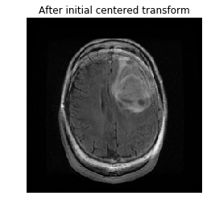

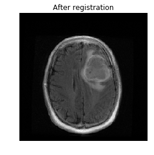

```python
# overlay images
display_images_with_alpha(80,0.4,img_T1,initial_FLAIRresample, 'After initial centered transform')
display_images_with_alpha(80,0.4,img_T1,FLAIR_resampled, 'After registration')
```

## Skull stripping through atlas based registration

I used the ICBM atlas http://nist.mni.mcgill.ca/?p=904 that includes a T1 image along with a brain mask. I define a skull strip function which allows the user to input any atlas+label file to perform the skull stripping. This function performs affine registration to account for differences in size of brain. I chose mutual information since it is robust to intensity differences between the fixed and moving images. The rest of the metrics are similar to the FLAIR/T1 registration.

```python
# function for skullstripping
def skullstrip(image, atlas, label):

    fixed_image = image
    moving_image = atlas
    initial_transform = sitk.CenteredTransformInitializer(fixed_image, moving_image,
                                                        sitk.AffineTransform(fixed_image.GetDimension()),
                                                        sitk.CenteredTransformInitializerFilter.GEOMETRY)
    registration_method = sitk.ImageRegistrationMethod()

    # Similarity metric settings.
    registration_method.SetMetricAsMattesMutualInformation(numberOfHistogramBins=50)
    registration_method.SetMetricSamplingStrategy(registration_method.RANDOM)
    registration_method.SetMetricSamplingPercentage(0.1)

    registration_method.SetInterpolator(sitk.sitkLinear)

    # Optimizer settings.
    registration_method.SetOptimizerAsGradientDescent(learningRate=1.0, numberOfIterations=100,
                                                      convergenceMinimumValue=1e-6, convergenceWindowSize=10)
    registration_method.SetOptimizerScalesFromPhysicalShift()

    # Setup for the multi-resolution framework.
    registration_method.SetShrinkFactorsPerLevel(shrinkFactors = [4,2,1])
    registration_method.SetSmoothingSigmasPerLevel(smoothingSigmas=[4,2,0])
    registration_method.SmoothingSigmasAreSpecifiedInPhysicalUnitsOn()

    registration_method.SetInitialTransform(initial_transform, inPlace=False)

    final_transform = registration_method.Execute(sitk.Cast(fixed_image, sitk.sitkFloat32),
                                                  sitk.Cast(moving_image, sitk.sitkFloat32))


    brainmask = sitk.Resample(label, fixed_image, final_transform, sitk.sitkNearestNeighbor,0.0,moving_image.GetPixelID())

    msk = sitk.MaskImageFilter()
    brainimage=msk.Execute(image,brainmask>0 )


    return brainimage, brainmask
```

Read the atlas images and perform skull stripping on T1 image

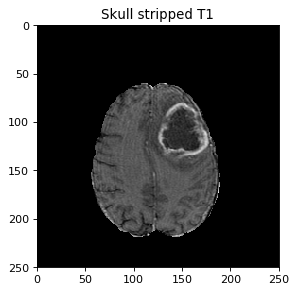

```python
# skull strip
atlas_T1 = sitk.ReadImage('../Data/Atlas/mni_icbm152_nlin_sym_09a/mni_icbm152_t1_tal_nlin_sym_09a.nii', sitk.sitkFloat32)
labelatlas_T1 = sitk.ReadImage('../Data/Atlas/mni_icbm152_nlin_sym_09a/mni_icbm152_t1_tal_nlin_sym_09a_mask.nii', sitk.sitkUInt8 )

atlas_T1_255 = sitk.Cast(sitk.RescaleIntensity(atlas_T1),sitk.sitkUInt8)



img_T1brain, brainmask = skullstrip(img_T1, atlas_T1, labelatlas_T1)
disp.myshow(img_T1brain[:,:,80], "Skull stripped T1")
```

Apply the same mask to the registered FLAIR image

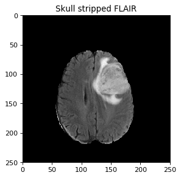

```python
#Apply the same mask to resampled FLAIR

msk = sitk.MaskImageFilter()
img_FLAIRbrain=msk.Execute(FLAIR_resampled,brainmask>0 )
disp.myshow(img_FLAIRbrain[:,:,80], "Skull stripped FLAIR")
```

```python
# write out images
sitk.WriteImage(img_T1brain, '../Results/3D_WAND_T1_WEIGHTED_skullstripped.nrrd')
sitk.WriteImage(img_FLAIRbrain, '../Results/AX_FLAIR_skullstripped.img')

# To visualize the labels image in RGB with needs a image with 0-255 range
img_T1brain_255 = sitk.Cast(sitk.RescaleIntensity(img_T1brain), sitk.sitkUInt8)
img_FLAIRbrain_255 = sitk.Cast(sitk.RescaleIntensity(img_FLAIRbrain), sitk.sitkUInt8)
```

# Segment hyperintense tumor from FLAIR

## Smoothing

I smooth the image using a curvature flow filter for denoising, since it is an edge preserving filter.

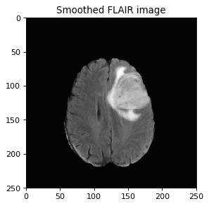

```python
blurFilter = sitk.CurvatureFlowImageFilter()
blurFilter.SetNumberOfIterations(5)
blurFilter.SetTimeStep(0.1)
blurredFLAIR=blurFilter.Execute(img_FLAIRbrain)
blurredFLAIR_255=sitk.RescaleIntensity(blurredFLAIR)
disp.myshow(blurredFLAIR[:,:,80], title='Smoothed FLAIR image')
```

```python
otsu_filter = sitk.OtsuMultipleThresholdsImageFilter()
otsu_filter.SetNumberOfThresholds(3)
otsu_filter.Execute(blurredFLAIR)
thresholds = otsu_filter.GetThresholds()
print('Thresholds =',thresholds)
segFLAIR = blurredFLAIR>thresholds[2]
```

```
Thresholds = (67.44263898729393, 170.95312177537988, 315.8677946269424)
```

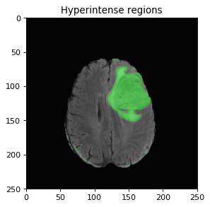

```python
disp.myshow(sitk.LabelOverlay(sitk.Cast(blurredFLAIR_255[:,:,80], sitk.sitkUInt8), segFLAIR[:,:,80]), "Hyperintense regions")
```

It can be seen that along with the tumor region, some CSF regions along the perimeter of the brain are also picked up

## Refine FLAIR tumor segmentation

The high intensity regions include the tumor, but also have some CSF. Additionally, in some cases, skull stripping might leave parts of skull. The following code isolates the tumor region by making the following assumptions:

- Tumor region is more spherical than CSF or skull regions that tend to be elongated:
  - Ratio of equivalent ellipsoid diameters close to 1 indicate more spherical than elongated. I defined the Elong metric as the squared difference of ratio from 1. Values close to zero indicate more spherical.
- We extract the largest hyperintense tumor in the brain, assuming we are only interested in the primary volume.

```python
# generate label image
conncomp = sitk.ConnectedComponentImageFilter()
seg = conncomp.Execute(segFLAIR)

# find label characteristics

stats = sitk.LabelShapeStatisticsImageFilter()
stats.Execute(seg)

labels = stats.GetLabels()
sizes=[]
elong = []
for lab in labels:
    dia=stats.GetEquivalentEllipsoidDiameter(lab)
    ratiodia = np.square(1- dia[1]/(dia[0]+1e-10))
    elong.append(ratiodia)
    sizes.append(stats.GetPhysicalSize(lab))
sizes=np.asarray(sizes)
elong = np.asarray(elong)
labels = np.asarray(labels)

labels= labels[~np.isnan(elong)]
sizes = sizes[~np.isnan(elong)]
elong = elong[~np.isnan(elong)]
```

We assume the following to separate the tumor region from other parts that have high intensity (e.g., remnant skull pieces or CSF)

- Elong metric < 0.25 ( 0 is perfect sphere)
- Largest region (assuming we want to segment the largest tumor)

```
Elong <0.25 = [ 0.18220143  0.19772582  0.14209217  0.01556687  0.09285232  0.20585922
  0.13387173]
Sizes corresponding to elong <0.25= [  1.35999792e+05   2.13622624e+01   3.35692695e+01   1.67846348e+01
   1.37328830e+01   2.89916419e+01   7.01902909e+01]
Choosing label corresponding to elong =0.182201 and size = 135999.792071
```

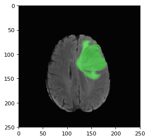

```python
#  with (1-ratio of ellipsoid diameters)^2 closest to zero, thresholding at 0.25
elong= np.asarray(elong)
sizes=np.asarray(sizes)
# find all the regions that have elong < 0.5
sphlabel_inds = np.where(elong<0.25)
# among those regions, pick the largest one
sizeinds = np.argmax(sizes[sphlabel_inds])
print('Elong <0.25 =', elong[sphlabel_inds])
print('Sizes corresponding to elong <0.25=', sizes[sphlabel_inds])

tlabel = labels[sphlabel_inds[0][sizeinds]]
tarr = sitk.GetArrayFromImage(seg)
tarr[tarr!=tlabel]=0
tarr[tarr>0]=1
segFLAIR = sitk.GetImageFromArray(tarr)
segFLAIR.CopyInformation(img_T1)
print("Choosing label corresponding to elong =%f and size = %f" %(elong[sphlabel_inds[0][sizeinds]], sizes[sphlabel_inds[0]][sizeinds]))
disp.myshow(sitk.LabelOverlay(sitk.Cast(blurredFLAIR_255[:,:,80], sitk.sitkUInt8), segFLAIR[:,:,80]))
```

The segmentation now isolated just the tumor region in the brain and dropped the regions around the perimeter. To ensure that there are no holes in the segmentation, I use an iterative hole filling filter.

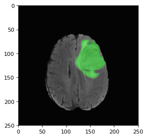

```python
holefill=sitk.VotingBinaryIterativeHoleFillingImageFilter()
holefill.SetMaximumNumberOfIterations(5)
segFLAIR=holefill.Execute(segFLAIR)
disp.myshow(sitk.LabelOverlay(sitk.Cast(blurredFLAIR_255[:,:,80],sitk.sitkUInt8), segFLAIR[:,:,80]))
```

## Segmentation of Tumor bulk from T1 image

## Smoothing

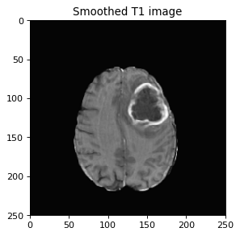

```python
# apply FLAIR segmentation mask to T1
blurFilter = sitk.CurvatureFlowImageFilter()
blurFilter.SetNumberOfIterations(5)
blurFilter.SetTimeStep(0.1)
blurredT1=blurFilter.Execute(img_T1brain)
disp.myshow(blurredT1[:,:,80], title='Smoothed T1 image')
```

Apply total tumor mask obtained from FLAIR to the T1 image

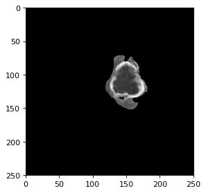

```python
# Apply FLAIR mask to T1 image
msk = sitk.MaskImageFilter()
blurredT1masked=msk.Execute(blurredT1,segFLAIR>0 )
disp.myshow(blurredT1masked[:,:,80])
```

# Thresholding

I use the Otsu multiple thresholds image filter again here to compute 3 thresholds (NE, CE, and the outer edema regions).

```
(26.34609031677246, 67.86114120483398, 109.37619400024414)
```

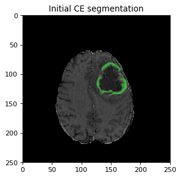

```python
otsu_filter = sitk.OtsuMultipleThresholdsImageFilter()
otsu_filter.SetNumberOfThresholds(3)

otsu_filter.Execute(blurredT1masked)
thresholdsT1 = otsu_filter.GetThresholds()
print(thresholdsT1)
segCE = blurredT1masked>thresholdsT1[2]
disp.myshow(sitk.LabelOverlay(img_T1brain_255[:,:,80], segCE[:,:,80]), "Initial CE segmentation")
```

# Segmentation of Necrotic region using Level Sets

I used the Threshold Segmentation Level Set filter, which uses level sets to propagate the front until it reaches the limits of an intensity window.

Intialization: The level set was initialized by eroding the total tumor label obtained from FLAIR.

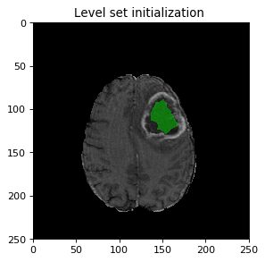

```python
binerode = sitk.BinaryErodeImageFilter()
binerode.SetKernelRadius(9)
erodedtumormask = binerode.Execute(segFLAIR>0)
disp.myshow(sitk.LabelOverlay(img_T1brain_255[:,:,80], erodedtumormask[:,:,80]), "Level set initialization ")
```

To generate a feature image for the level set filter, we compute the Euclidean distance fuction of the binary FLAIR segmentation. The parameters of the level set were chosen as:

- Intensity window: Lower threshold was chosen same as the one used above for CE segmentation. Upper threshold was chosen to be 3 times the lower threshold. This will lock the level set at a value greater than the CE threshold.
- Propagation scaling: A positive value corresponds to expansion. Since we are expanding to fill the necrotic region, I chose a positive value.
- Curvature scaling: Determines the smoothness of the resulting mask.  
  The parameters were chosen below to give the best results visually. For a larger dataset, a grid search may be performed to obtain the best agreement (coefficient of overlap) with ground truth labels.

```python
init_ls = sitk.SignedMaurerDistanceMap(erodedtumormask, insideIsPositive=True, useImageSpacing=True)
```

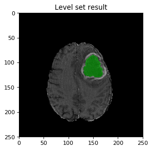

```python
lsFilter = sitk.ThresholdSegmentationLevelSetImageFilter()
lsFilter.SetLowerThreshold(thresholdsT1[2])
lsFilter.SetUpperThreshold(3*thresholdsT1[2])
lsFilter.SetMaximumRMSError(0.05)
lsFilter.SetNumberOfIterations(300)
lsFilter.SetCurvatureScaling(1.0)
lsFilter.SetPropagationScaling(1)
ls = lsFilter.Execute(init_ls, sitk.Cast(blurredT1masked, sitk.sitkFloat32))
disp.myshow(sitk.LabelOverlay(img_T1brain_255[:,:,80], ls[:,:,80]>0), 'Level set result')
```

I then combine CE and NE masks and use several iterations of iterative holefill to fill in the gaps between the CE and NE regions.

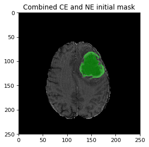

```python
seg  = segCE+sitk.Cast(ls>0, sitk.sitkUInt8)
seg=sitk.Cast(seg>0,sitk.sitkUInt8)
disp.myshow(sitk.LabelOverlay(img_T1brain_255[:,:,80], seg[:,:,80]>0),'Combined CE and NE initial mask')
```

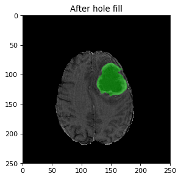

```python
holefill=sitk.VotingBinaryIterativeHoleFillingImageFilter()
holefill.SetMaximumNumberOfIterations(40)
segTumorbulk=holefill.Execute(seg)

disp.myshow(sitk.LabelOverlay(img_T1brain_255[:,:,80], segTumorbulk[:,:,80]>0),'After hole fill')
```

# Compute Dice coefficients

```python
Truelabel = sitk.ReadImage('../Data/3D_WAND_T1_WEIGHTED-label.nrrd', sitk.sitkUInt8)
```

```python
Truelabel_arr = sitk.GetArrayFromImage(Truelabel)
# the label file had labels 0 and 9 which was causing issues with the simpleitk dice coefficient computation
# changing the label 9 to 1
Truelabel_arr[Truelabel_arr>0]=1
Truelabel = sitk.GetImageFromArray(Truelabel_arr)
Truelabel.CopyInformation(img_T1)
dc = sitk.LabelOverlapMeasuresImageFilter()
dc.Execute(Truelabel, segTumorbulk)
DiceCoef= dc.GetDiceCoefficient()
print('Dice coefficient = ',DiceCoef)
```

```
Dice coefficient =  0.8956254344522072
```

```python
sitk.WriteImage(segFLAIR, '../Results/AX_FLAIR_Totaltumorseg.nrrd')
sitk.WriteImage(segTumorbulk, '../Results/3D_WAND_T1_WEIGHTED_Tumorbbulkseg.nrrd')
```

# References

[1] Grossmann, Patrick et al. “Imaging-Genomics Reveals Driving Pathways of MRI Derived Volumetric Tumor Phenotype Features in Glioblastoma.” BMC Cancer 16 (2016): 611. PMC. Web. 18 Dec. 2017. https://www.ncbi.nlm.nih.gov/pmc/articles/PMC4977720/

[2] Velasquez, Meier, et al., Fully automatic GBM segmentation in the TCGA-GBM dataset: Prognosis and correlation with VASARI features,Nature Scientific Reports 5 (2015) http://www.nature.com/articles/srep16822